# Curated Processing

Haozheng Xu

2026-04-06

# 1 Overview

NeuroVault, (https://neurovault.org/), is an open repository for sharing unthresholded statistical maps, parcellations, and atlases of the human brain. People share the brain images that they use for their studies to the website, to allow for interactive visualization of images while also contributing data entries for meta-analysis. This project is a meta-analysis over the available brain images on NeuroVault.

However, since investigators use the images for different purposes, retrieve images from different sources (e.g. different MRI machines), the images are not calibrated for collective analysis. This is why a preprocessing pipeline is necessary. In this project, we standardize the images to a common space (MNI 2mm), resolution, and intensity scale (RESI) to allow for further meta-analysis of the valuable image data. Since images on NeuroVault is constantly updating up until today, we aim to have this preprocessing pipeline updated monthly to capture all newly added images, to gradually accumulate as a comprehensive preprocessed dataset for future use.

# 2 Download the Neurovault data

```r
library(parallel)
library(RNifti)
library(pbj)
library(abind)
library(dplyr)
library(table1)
library(GGally)
library(ggplot2)
library(httr)
library(jsonlite)
library(ComplexUpset)
library(tidyr)

knitr::knit_hooks$set(GPs=function(before, options, envir){
  if (before){
    cex=1.5
    par(mgp=c(1.8,.7,0), lwd=2, lend=2,
        cex.lab=cex, cex.axis=cex, cex.main=1*cex,
        mar=c(2.8,3,1.8,.5), bty='l', oma=c(0,0,2,0))}
})
knitr::opts_chunk$set(echo = TRUE, fig.height = 7.5, fig.width = 7.5, GPs=TRUE, cache=FALSE)

# visualize mean image
template = "/usr/local/fsl/data/standard/MNI152_T1_2mm_brain.nii.gz"
template_mask = "/usr/local/fsl/data/standard/MNI152_T1_2mm_brain_mask.nii.gz"
# this is the abide study mask
abidemaskfile = file.path('/media/disk2/home/vandeks/vandekar_R01_renewal_2024/analyses', 'abide/neuroimaging/cpac/mask_2mm.nii.gz')
# this is the neurovault mask
maskfile='/media/disk2/home/vandeks/vandekar_R01_renewal_2024/analyses/mask.nii.gz'
# for the analysis, a combined mask is used.

# Number of cores
n_cores <- 24
```

## 2.1 Metadata download and exclusionary criteria

The Neurovault metadata include manually entered information at the study- and image-level describing the type of data that were uploaded. The Neurovault data contain the following variables that we use in the data preprocessing:

- `analysis_level`: indicates whether the image is a group-level or individual-level statistical map.
- `not_mni`: indicates whether the image is in MNI space.
- `is_thresholded`: indicates whether the image is thresholded or unthresholded.
- `map_type`: indicates the statistical type of the image (e.g., T, Z, F).
- `perc_bad_voxels`: Proportion of voxels with 0 intensity or NaN values.
- `perc_voxels_outside`: Proportion of voxels outside the brain.
- `number_of_subjects`: Sample size of the study

We download the Neurovault study-level and image-level metadata, then apply quality exclusionary criteria to the metadata to ensure uniformity of the group-level statistical images. Specifically, we:

- Retain only group-level images, which represent aggregate statistical maps rather than individual-level contrasts (`analysis_level == "group"`).
- Exclude images that are not in MNI space (`not_mni == FALSE`).
- Keep only unthresholded maps (`is_thresholded == FALSE`), which ensures all statistical values computed in the image are included. This avoids biased caused by only reporting significant results
- Restrict to statistical image types T and Z images, which are most commonly used in group-level inference. This step removes less frequently reported F images, and non-statistical images.
- Exclude those that have sample size of 0 or NaN.

```r
Sys.setenv(CURL_CA_BUNDLE = "/etc/ssl/certs/ca-certificates.crt")
httr::GET("https://api.github.com")

url <- 'https://neurovault.org/api/collections/?format=json'

nv = list()
i = 0
while (!is.null(url)) {
  i = i + 1
  cat(i, '\t')
  response <- GET(url, config(cainfo="/etc/ssl/certs/ca-certificates.crt"))
  data <- content(response, "text")
  json_data <- fromJSON(data, flatten = TRUE)
  nv[[i]] = json_data$results

  url <- json_data[['next']]
}
nv = do.call(rbind, nv)
# number of repos with DOIs
#sum(!is.na(nv$DOI))
# subset to studies that have more than 0 images
nv = nv[nv$number_of_images>0,]
saveRDS(nv, file='neurovaultMetadata.rds')
```

```r
nv =readRDS(file='neurovaultMetadata.rds')
```

```r
# same thing for the image data

 url <- paste0("https://neurovault.org/api/images/?format=json")
 results = list()
 i = 0
 while (!is.null(url)) {
   i = i + 1
   cat(i, '\t')
   response <- GET(url)
   data <- content(response, "text")
   json_data <- fromJSON(data, flatten = TRUE)
   results[[i]] = json_data$results

   url <- json_data[['next']]
 }
 saveRDS(results, file='imageMetadata.rds')

images = lapply(nv$id, function(collection_id){
   message(collection_id)
  url <- paste0("neurovault.org/api/collections/", collection_id, "/images")

  response <- GET(url)
  data <- content(response, "text")
  json_data <- fromJSON(data, flatten = TRUE)
  json_data$results
})

# Keep only data frames with ≥53 columns
images <- images[ sapply(images, is.data.frame) & sapply(images, ncol) >= 53 ]

# Split into chunks
chunked_images <- split(images, sort(seq_along(images) %% n_cores))

# Tracker function
progress_fun <- function(i, total) {
  cat(sprintf("Chunk %d of %d merged [%s]\n", i, total, Sys.time()))
}

# Merge within each chunk (in parallel)
partial_merged <- mclapply(seq_along(chunked_images), function(i) {
  chunk <- chunked_images[[i]]
  merged_chunk <- Reduce(function(x, y) merge(x, y, all = TRUE), chunk)
  progress_fun(i, length(chunked_images))
  return(merged_chunk)
}, mc.cores = n_cores)

# Merge final chunks (sequentially — usually < 8, so fast)
cat("Final merge of all chunks...\n")
images_merged <- Reduce(function(x, y) merge(x, y, all = TRUE), partial_merged)

# Save
saveRDS(images_merged, "fullimageMetadata.rds") # This methodology gives a dataset with more than 1000 columns
```

```r
library(forcats)
library(grid)
library(ComplexUpset)
images <- readRDS("fullimageMetadata.rds")

images <- images %>% mutate(
  image_type      = factor(image_type,      levels = names(sort(table(image_type),      decreasing = TRUE))),
  map_type        = factor(map_type,        levels = names(sort(table(map_type),        decreasing = TRUE))),
  analysis_level  = factor(analysis_level,  levels = names(sort(table(analysis_level),  decreasing = TRUE))),
  is_thresholded  = factor(is_thresholded,  levels = names(sort(table(is_thresholded),  decreasing = TRUE))),
  not_mni         = factor(not_mni,         levels = names(sort(table(not_mni),         decreasing = TRUE)))
)

table1(~ image_type + map_type + analysis_level + is_thresholded + not_mni,
       data = images,
       caption = "Table 1: Raw collection of all data")
```

Table 1: Raw collection of all data

|  | Overall (N=543699) |
| --- | --- |
| image_type |  |
| statistic_map | 543000 (99.9%) |
| NIDM results statistic map | 681 (0.1%) |
| atlas | 18 (0.0%) |
| map_type |  |
| univariate-beta map | 152257 (28.0%) |
| variance | 138378 (25.5%) |
| Z map | 99864 (18.4%) |
| other | 67989 (12.5%) |
| T map | 67563 (12.4%) |
| ROI/mask | 9509 (1.7%) |
| P map (given null hypothesis) | 4502 (0.8%) |
| parcellation | 1068 (0.2%) |
| F map | 1031 (0.2%) |
| 1-P map ("inverted" probability) | 533 (0.1%) |
| anatomical | 477 (0.1%) |
| multivariate-beta map | 467 (0.1%) |
| Chi squared map | 43 (0.0%) |
| Missing | 18 (0.0%) |
| analysis_level |  |
| single-subject | 408986 (75.2%) |
| group | 45479 (8.4%) |
| meta-analysis | 10184 (1.9%) |
| other | 2158 (0.4%) |
|  | 27 (0.0%) |
| Missing | 76865 (14.1%) |
| is_thresholded |  |
| FALSE | 482019 (88.7%) |
| TRUE | 54943 (10.1%) |
| Missing | 6737 (1.2%) |
| not_mni |  |
| FALSE | 541415 (99.6%) |
| TRUE | 2266 (0.4%) |
| Missing | 18 (0.0%) |

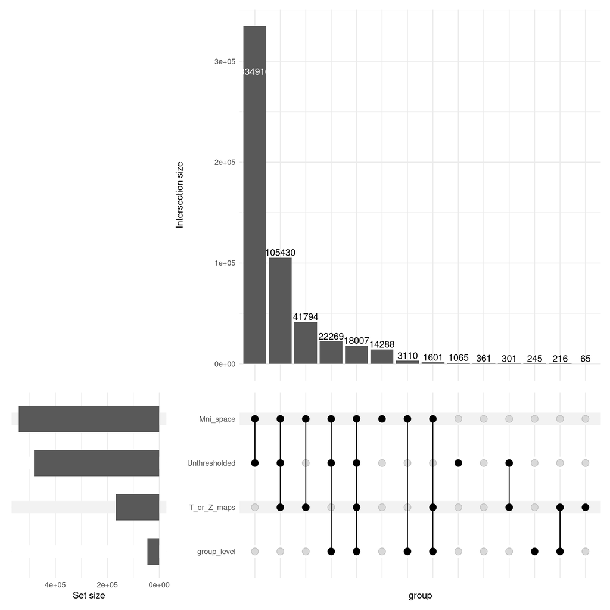

Figure 1: Overlap of NeuroVault Image Characteristics

```r
## UpSet table
images$binarized_group_level <- ifelse(images$analysis_level == "group", TRUE, FALSE)
images$binarized_map_type <- ifelse(images$map_type == "T map" | images$map_type == "Z map", TRUE, FALSE)
images$unthresholded <- ifelse(images$is_thresholded == FALSE, TRUE, FALSE)
images$mni <- ifelse(images$not_mni == FALSE, TRUE, FALSE)

images_clean <- images %>%
  transmute(
    group_level = as.logical(binarized_group_level),
    T_or_Z_maps   = as.logical(binarized_map_type),
    Unthresholded = as.logical(unthresholded),
    Mni_space   = as.logical(mni)
  )

upset(
  images_clean,
  intersect = c("group_level", "T_or_Z_maps", "Unthresholded", "Mni_space"),
  min_size        = 50,
  base_annotations = list('Intersection size' = intersection_size())
)
```

**Note**:

1. The `analysis_level` variable has other types of data, and group-level images make up less than 10% of data.
2. Including only T and Z maps removes approximately 70% of the data.

```r
images <- readRDS("fullimageMetadata.rds")
# The following starts the trimming progress
# sort columns by nonmissingness
images = images[ ,order(colMeans(is.na(images)))]

# get the first 47 columns, which seemed to make sense
images = images[,1:47]

# subset to group-level analysis
images = images[ which(images$analysis_level=='group'), ]
# subset to unthresholded images
images = images[which(images$is_thresholded==FALSE),]
# Including only T and Z map types
images = images[images$map_type %in% c("T map", "Z map"), ]
# Exclude all not mni
images = images[which(images$not_mni == FALSE), ]
# Exclude sample size 0
images <- subset(images, !is.na(number_of_subjects))

table1(~ image_type + map_type + analysis_level + is_thresholded + not_mni + number_of_subjects, data = images, caption = "Table 2: Preliminary sorting")
```

Table 2: Preliminary sorting

|  | Overall (N=17796) |
| --- | --- |
| image_type |  |
| statistic_map | 17796 (100%) |
| NIDM results statistic map | 0 (0%) |
| atlas | 0 (0%) |
| map_type |  |
| univariate-beta map | 0 (0%) |
| variance | 0 (0%) |
| Z map | 2419 (13.6%) |
| other | 0 (0%) |
| T map | 15377 (86.4%) |
| ROI/mask | 0 (0%) |
| P map (given null hypothesis) | 0 (0%) |
| parcellation | 0 (0%) |
| F map | 0 (0%) |
| 1-P map ("inverted" probability) | 0 (0%) |
| anatomical | 0 (0%) |
| multivariate-beta map | 0 (0%) |
| Chi squared map | 0 (0%) |
| analysis_level |  |
| single-subject | 0 (0%) |
| group | 17796 (100%) |
| meta-analysis | 0 (0%) |
| other | 0 (0%) |
|  | 0 (0%) |
| is_thresholded |  |
| FALSE | 17796 (100%) |
| TRUE | 0 (0%) |
| not_mni |  |
| FALSE | 17796 (100%) |
| TRUE | 0 (0%) |
| number_of_subjects |  |
| Mean (SD) | 1880 (242000) |
| Median [Min, Max] | 27.0 [1.00, 32200000] |

```r
saveRDS(images, "imageMetadata.rds")
```

## 2.2 Imaging data download

```r
images <- readRDS("imageMetadata.rds")
# download the images
outdir = '/media/big/neurovault'
images$localfile = gsub('http://neurovault.org/media/images', outdir, images$file)

# creates the directories
invisible(capture.output(lapply(unique(dirname(images$localfile)), dir.create, showWarnings=FALSE, recursive = TRUE)))

# Actually download the images, here, if they aren't already
# downloaded. I am not sure if there are usage limits on
# neurovault. This parallel call would probably be a problem
# if there is. There were issues the first time.
images$download = !file.exists(images$localfile)
# tryCatch to ignore errors
downloadFile = function(url, destfile){ tryCatch(download.file(url=url, destfile=destfile), error=function(e){NA})}
mcmapply(downloadFile, url=images$file[ images$download==TRUE], destfile=images$localfile[ images$download==TRUE], mc.cores = n_cores)
# recheck what files exist
images$download = !file.exists(images$localfile)
saveRDS(images, 'imageMetadata.rds')
```

```r
images = readRDS('imageMetadata.rds')

images$target_template_image <- factor(images$target_template_image,
                                       levels = names(sort(table(images$target_template_image), decreasing = TRUE)))

images$image_type <- factor(images$image_type,
                                   levels = names(sort(table(images$image_type), decreasing = TRUE)))

images$map_type <- factor(images$map_type,
                                 levels = names(sort(table(images$map_type), decreasing = TRUE)))

images$analysis_level <- factor(images$analysis_level,
                                       levels = names(sort(table(images$analysis_level), decreasing = TRUE)))

images$is_thresholded <- factor(images$is_thresholded,
                                       levels = names(sort(table(images$is_thresholded), decreasing = TRUE)))

images$not_mni <- factor(images$not_mni,
                                levels = names(sort(table(images$not_mni), decreasing = TRUE)))

table1(~ target_template_image + image_type + map_type + analysis_level + is_thresholded + not_mni + perc_bad_voxels + brain_coverage + perc_voxels_outside, data = images, caption = "Table 3: image data overview")
```

Table 3: image data overview

|  | Overall (N=17796) |
| --- | --- |
| target_template_image |  |
| GenericMNI | 16125 (90.6%) |
| MNI152NLin2009cAsym | 1631 (9.2%) |
| NMT | 39 (0.2%) |
| Dorr2008 | 1 (0.0%) |
| image_type |  |
| statistic_map | 17796 (100%) |
| NIDM results statistic map | 0 (0%) |
| atlas | 0 (0%) |
| map_type |  |
| T map | 15377 (86.4%) |
| Z map | 2419 (13.6%) |
| univariate-beta map | 0 (0%) |
| variance | 0 (0%) |
| other | 0 (0%) |
| ROI/mask | 0 (0%) |
| P map (given null hypothesis) | 0 (0%) |
| parcellation | 0 (0%) |
| F map | 0 (0%) |
| 1-P map ("inverted" probability) | 0 (0%) |
| anatomical | 0 (0%) |
| multivariate-beta map | 0 (0%) |
| Chi squared map | 0 (0%) |
| analysis_level |  |
| group | 17796 (100%) |
| single-subject | 0 (0%) |
| meta-analysis | 0 (0%) |
| other | 0 (0%) |
|  | 0 (0%) |
| is_thresholded |  |
| FALSE | 17796 (100%) |
| TRUE | 0 (0%) |
| not_mni |  |
| FALSE | 17796 (100%) |
| TRUE | 0 (0%) |
| perc_bad_voxels |  |
| Mean (SD) | 72.0 (13.3) |
| Median [Min, Max] | 74.7 [0, 86.1] |
| brain_coverage |  |
| Mean (SD) | 93.3 (11.7) |
| Median [Min, Max] | 98.6 [2.66, 100] |
| perc_voxels_outside |  |
| Mean (SD) | 18.7 (23.1) |
| Median [Min, Max] | 15.5 [0, 100] |

# 3 Image derived exclusionary criteria

```r
library(RNifti)
library(parallel)
library(papayaWidget)

# check dimensions of voxels and generating the voxel and image dimensions
images = readRDS('imageMetadata.rds')
images = images[ !images$download,]
cmd = paste('/usr/local/c3d-1.1.0-Linux-x86_64/bin/c3d', images$localfile, '-info')
voxdim = mclapply(cmd, system, intern=TRUE, mc.cores=n_cores)
images$voxdim = unlist(lapply(voxdim, function(x){splt = strsplit(x[1], split = ';')[[1]]; splt[grep('vox', splt)] }))
images$imgdim = unlist(lapply(voxdim, function(x){splt = strsplit(x[1], split = ';')[[1]]; splt[grep('dim', splt)] }))
images$voxdim <- trimws(images$voxdim)
images$imgdim <- trimws(images$imgdim)

# Count non-zero voxels
cmd_vox <- paste('/usr/local/c3d-1.1.0-Linux-x86_64/bin/c3d', images$localfile, '-threshold 0 0 0 1 -voxel-sum')
nvox <- unlist(mclapply(cmd_vox, system, intern = TRUE, mc.cores = n_cores))
images$nvox <- as.numeric(gsub("[^0-9.]", "", nvox))  # allow decimals just in case

# Get orientation, range, and bounding box from `-info` output
cmd_info <- paste('/usr/local/c3d-1.1.0-Linux-x86_64/bin/c3d', images$localfile, '-info')
info <- mclapply(cmd_info, system, intern = TRUE, mc.cores = n_cores)

# Helper function to extract value by keyword from a string
extract_info_field <- function(lines, keyword) {
  val <- sapply(lines, function(x) {
    first_line <- x[1]
    splt <- strsplit(first_line, split = ";")[[1]]
    match <- grep(keyword, splt, value = TRUE)
    if (length(match) > 0) {
      return(trimws(sub(paste0("^.*", keyword, "\\s*=\\s*"), "", match[1])))
    } else {
      return(NA)
    }
  })
  return(val)
}

images$orient <- extract_info_field(info, "orient")
images$range <- extract_info_field(info, "range")
images$bounding_box <- extract_info_field(info, "bb")
images$voxdim <- trimws(gsub("vox = ", "", images$voxdim))
images$imgdim <- trimws(gsub("Image #1: dim = ", "", images$imgdim))

# Save
saveRDS(images, "imageMetadataSubset.rds")
```

```r
images <- readRDS("imageMetadataSubset.rds")

library(data.table)

if (is.list(images) && !is.data.frame(images)) {
  keep <- vapply(images, function(x) is.data.frame(x) && nrow(x) > 0, logical(1))
  DF <- rbindlist(images[keep], use.names = TRUE, fill = TRUE)
}
setDT(DF)
DF[, row_id := .I]   # keep original row index

# Add basename(localfile)
  DF[, localfile_base := basename(as.character(localfile))]


# Choose candidate key columns (use only those that exist)
cand_keys <- c("perc_bad_voxels","brain_coverage","range","bounding_box",
               "nvox","imgdim","localfile_base")

# Build a key-only copy and normalize any list columns
keyDF <- copy(DF[, ..cand_keys])

# Turn list-like columns into comparable strings
list_cols <- names(Filter(is.list, keyDF))
  keyDF[, (list_cols) := lapply(.SD, function(x)
    vapply(x, function(z) paste(as.character(z), collapse = "x"), character(1))
  ), .SDcols = list_cols]


# Create a stable group key for analysis (using normalized keyDF)
grp_key <- do.call(paste, c(keyDF, sep = "|"))
DF[, grp_key := grp_key]

# Flag all rows that belong to a duplicated group
dup_flag <- duplicated(keyDF) | duplicated(keyDF, fromLast = TRUE)

# The full duplicates dataset for analysis
dups <- DF[dup_flag]

  dups[, dup_count := .N, by = grp_key]
  setorder(dups, -dup_count)


# Quick summary of duplicate groups for spot checking
dup_groups <- unique(dups[, .(grp_key, dup_count)])[order(-dup_count)]

# DEDUPLICATION: Use consistent approach with normalized keyDF

  keep_rows <- !duplicated(keyDF)
  DF_dedup <- DF[keep_rows]


# Verify results
cat("Original rows:", nrow(DF), "\n")
cat("After deduplication:", nrow(DF_dedup), "\n")
cat("Duplicates removed:", nrow(DF) - nrow(DF_dedup), "\n")

# Remove temporary analysis columns if desired
DF_dedup[, c("grp_key") := NULL]


saveRDS(DF_dedup, 'imageMetadataSubset2.2.rds')
```

```r
images = readRDS('imageMetadataSubset2.2.rds')
library(table1)
## factorize so that it appears in descending order
images$voxdim <- as.factor(images$voxdim)
voxdim_freq <- table(images$voxdim)
voxdim_sorted <- names(sort(voxdim_freq, decreasing = TRUE))
images$voxdim <- factor(images$voxdim, levels = voxdim_sorted)
images$map_type <- as.factor(images$map_type)
map_type_freq   <- table(images$map_type)
map_type_sorted <- names(sort(map_type_freq, decreasing = TRUE))
images$map_type <- factor(images$map_type, levels = map_type_sorted)
images$imgdim <- as.factor(images$imgdim)
imgdim_freq <- table(images$imgdim)
imgdim_sorted <- names(sort(imgdim_freq, decreasing = TRUE))
images$imgdim <- factor(images$imgdim, levels = imgdim_sorted)

images$bounding_box <- as.factor(images$bounding_box)
bbox_freq <- table(images$bounding_box)
bbox_sorted <- names(sort(bbox_freq, decreasing = TRUE))
images$bounding_box <- factor(images$bounding_box, levels = bbox_sorted)

table1(~ imgdim +voxdim + nvox + map_type + perc_bad_voxels + perc_voxels_outside + bounding_box + number_of_subjects, data = images, caption = "Table 4: Raw data and dimension inspection")
```

[output not shown]

```r
images <- readRDS('MeaningfulimageMetadataSubset3.1.rds')

# Split dim_mm into x, y, z components
dims_split <- strsplit(images$dim_mm, "\\*")
dims_mat <- do.call(rbind, lapply(dims_split, as.numeric))
colnames(dims_mat) <- c("dim_x", "dim_y", "dim_z")

# Compute ratios
ratio_xy <- dims_mat[,1] / dims_mat[,2]
ratio_xz <- dims_mat[,1] / dims_mat[,3]
ratio_yz <- dims_mat[,2] / dims_mat[,3]

# Define reference ratios (from MNI: 182x218x182)
ref_xy <- 182 / 218       # ≈ 0.8349
ref_xz <- 1               # since x = z
ref_yz <- 218 / 182       # ≈ 1.1978

# Set epsilon
epsilon <- 0.025

# Logical mask for proportional dimensions
is_proportional <- abs(ratio_xy - ref_xy) < epsilon &
                   abs(ratio_xz - ref_xz) < epsilon &
                   abs(ratio_yz - ref_yz) < epsilon

# Subset original data
images_subset <- images[is_proportional, ]

#sort(table(images_subset$dim_mm),decreasing = TRUE)

images_subset$dim_mm <- as.factor(images_subset$dim_mm)
dim_mm_freq <- table(images_subset$dim_mm)
dim_mm_sorted <- names(sort(dim_mm_freq, decreasing = TRUE))
images_subset$dim_mm <- factor(images_subset$dim_mm, levels = dim_mm_sorted)

saveRDS(images_subset, "proportionalimagesubset_Section3.1.2.rds")
prop_near_mni <- nrow(images_subset)
mni_total <- nrow(images)
table1(~ dim_mm + nvox + map_type + perc_bad_voxels + perc_voxels_outside, data = images_subset, caption = "Table 4: Milimeter data distribution of subsetted dataset")
```

Table 4: Milimeter data distribution of subsetted dataset

|  | Overall (N=14087) |
| --- | --- |
| dim_mm |  |
| 182*218*182 | 3200 (22.7%) |
| 195*231*196 | 2459 (17.5%) |
| 194*230*194 | 2085 (14.8%) |
| 195*231*195 | 1290 (9.2%) |
| 192*228*192 | 1092 (7.8%) |
| 158*190*158 | 806 (5.7%) |
| 195*232.5*195 | 698 (5.0%) |
| 181.5*217.5*181.5 | 487 (3.5%) |
| 196.749*230.755*194.4 | 413 (2.9%) |
| 183*219*183 | 321 (2.3%) |
| 194*230*194.4 | 288 (2.0%) |
| 159*189*156 | 267 (1.9%) |
| 184.25*220*184 | 72 (0.5%) |
| 157.5*192.5*157.5 | 68 (0.5%) |
| 180*216*180 | 63 (0.4%) |
| 158*190*156 | 59 (0.4%) |
| 194.4*230.4*194.4 | 59 (0.4%) |
| 194*230*195 | 45 (0.3%) |
| 196.218*231.894*196.42 | 33 (0.2%) |
| 181*217*181 | 24 (0.2%) |
| 180*217.5*180 | 20 (0.1%) |
| 193.2*229.2*193.2 | 20 (0.1%) |
| 188*220*184 | 19 (0.1%) |
| 182*217*182 | 18 (0.1%) |
| 157.5*190.5*157.5 | 15 (0.1%) |
| 196*232*197.6 | 15 (0.1%) |
| 194.247*230.346*195 | 14 (0.1%) |
| 195.8*231*195.8 | 14 (0.1%) |
| 182.5*220*182.5 | 13 (0.1%) |

[output cut: 53 more lines]

Using a proportionality tolerance of $\varepsilon$ = 0.025, we find that 88% of images are approximately proportional to the MNI template.

```r
images <- readRDS('MeaningfulimageMetadataSubset3.1.rds')

# Split dim_mm into x, y, z components
dims_split <- strsplit(images$dim_mm, "\\*")
dims_mat <- do.call(rbind, lapply(dims_split, as.numeric))
colnames(dims_mat) <- c("dim_x", "dim_y", "dim_z")

# Compute ratios
ratio_xy <- dims_mat[,1] / dims_mat[,2]
ratio_xz <- dims_mat[,1] / dims_mat[,3]
ratio_yz <- dims_mat[,2] / dims_mat[,3]

# Define reference ratios (from MNI: 182x218x182)
ref_xy <- 182 / 218       # ≈ 0.8349
ref_xz <- 1               # since x = z
ref_yz <- 218 / 182       # ≈ 1.1978

# Set epsilon
epsilon <- 0.025

# Logical mask for proportional dimensions
is_proportional <- abs(ratio_xy - ref_xy) < epsilon &
                   abs(ratio_xz - ref_xz) < epsilon &
                   abs(ratio_yz - ref_yz) < epsilon

# Subset original data
images_subset <- images[is_proportional, ]

#sort(table(images_subset$dim_mm),decreasing = TRUE)

images_subset$dim_mm <- as.factor(images_subset$dim_mm)
dim_mm_freq <- table(images_subset$dim_mm)
dim_mm_sorted <- names(sort(dim_mm_freq, decreasing = TRUE))
images_subset$dim_mm <- factor(images_subset$dim_mm, levels = dim_mm_sorted)

saveRDS(images_subset, "proportionalimagesubset_Section3.1.2.rds")
table1(~ dim_mm + nvox + map_type + perc_bad_voxels + perc_voxels_outside, data = images_subset, caption = "Table 5: Milimeter data distribution of subsetted dataset")
```

Table 5: Milimeter data distribution of subsetted dataset

|  | Overall (N=14087) |
| --- | --- |
| dim_mm |  |
| 182*218*182 | 3200 (22.7%) |
| 195*231*196 | 2459 (17.5%) |
| 194*230*194 | 2085 (14.8%) |
| 195*231*195 | 1290 (9.2%) |
| 192*228*192 | 1092 (7.8%) |
| 158*190*158 | 806 (5.7%) |
| 195*232.5*195 | 698 (5.0%) |
| 181.5*217.5*181.5 | 487 (3.5%) |
| 196.749*230.755*194.4 | 413 (2.9%) |
| 183*219*183 | 321 (2.3%) |
| 194*230*194.4 | 288 (2.0%) |
| 159*189*156 | 267 (1.9%) |
| 184.25*220*184 | 72 (0.5%) |
| 157.5*192.5*157.5 | 68 (0.5%) |
| 180*216*180 | 63 (0.4%) |
| 158*190*156 | 59 (0.4%) |
| 194.4*230.4*194.4 | 59 (0.4%) |
| 194*230*195 | 45 (0.3%) |
| 196.218*231.894*196.42 | 33 (0.2%) |
| 181*217*181 | 24 (0.2%) |
| 180*217.5*180 | 20 (0.1%) |
| 193.2*229.2*193.2 | 20 (0.1%) |
| 188*220*184 | 19 (0.1%) |
| 182*217*182 | 18 (0.1%) |
| 157.5*190.5*157.5 | 15 (0.1%) |
| 196*232*197.6 | 15 (0.1%) |
| 194.247*230.346*195 | 14 (0.1%) |
| 195.8*231*195.8 | 14 (0.1%) |
| 182.5*220*182.5 | 13 (0.1%) |

[output cut: 53 more lines]

@haozheng, because this depends on the initial image derived values, it should be moved up and executed with the exclusionary criteria at the top of this section. Include the plots.

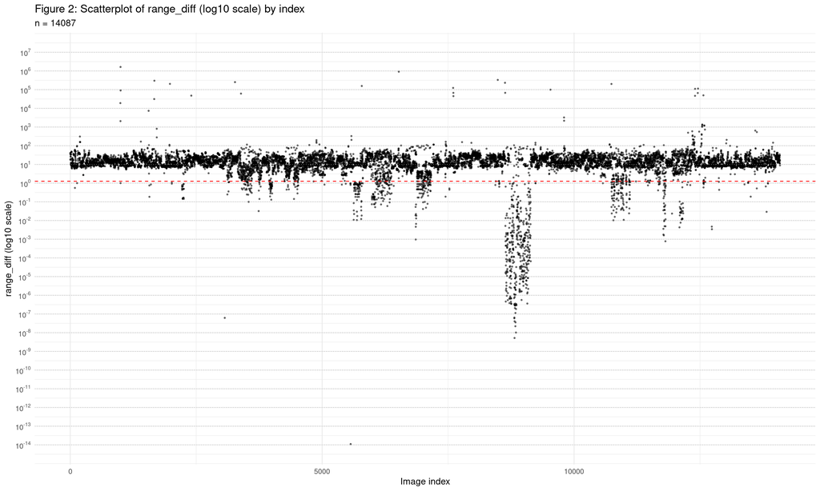

Scatter of range_diff (log10 scale) by index

```r
library(stringr)
library(ggplot2)
library(scales)

images <- readRDS("proportionalimagesubset_Section3.1.2.rds")

# parse [lo, hi]
m <- str_match(
  images[["range"]],
  "\\[\\s*([+-]?(?:\\d*\\.?\\d+(?:[eE][+-]?\\d+)?))\\s*,\\s*([+-]?(?:\\d*\\.?\\d+(?:[eE][+-]?\\d+)?))\\s*\\]"
)
lo <- as.numeric(m[, 2])
hi <- as.numeric(m[, 3])

# attach & compute range
images$range_low  <- lo
images$range_high <- hi
images$range_diff <- images$range_high - images$range_low

# histogram of log10(range_diff) (positive values only)
xpos <- images$range_diff
xpos <- xpos[is.finite(xpos) & xpos > 0]

# xpos already defined above as positive, finite range_diff values
df_sc <- data.frame(
  idx = seq_along(xpos),
  l10 = log10(xpos)
)

tick_min <- floor(min(df_sc$l10, na.rm = TRUE))
tick_max <- ceiling(max(df_sc$l10, na.rm = TRUE))
ticks    <- tick_min:tick_max

ggplot(df_sc, aes(idx, l10)) +
  geom_point(alpha = 0.5, size = 0.6) +
  scale_y_continuous(breaks = ticks, labels = scales::math_format(10^.x)) +
  geom_hline(yintercept = ticks, linetype = "dotted", linewidth = 0.3, color = "grey70") +
  labs(
    title = "Figure 2: Scatterplot of range_diff (log10 scale) by index",
    x = "Image index",
    y = "range_diff (log10 scale)",
    subtitle = sprintf("n = %d ", length(xpos))
  ) +
  geom_hline(yintercept = 0.1,linetype = "dashed", color = "red") +
  theme_minimal(base_size = 12)
```

```r
# drop rows with log10(range_diff) < 0.1 (guard against non-positive / NA)
thr <- 0.1
idx_drop <- which(is.finite(images$range_diff) &
                  images$range_diff > 0 &
                  log10(images$range_diff) < thr)

images <- images[-idx_drop, , drop = FALSE]
cat("Removed:", length(idx_drop), "rows\n")
```

```
## Removed: 993 rows
```

```r
saveRDS(images, "proportionalimagesubset_Section3.1.3.rds")
```

# 4 Rigid registration

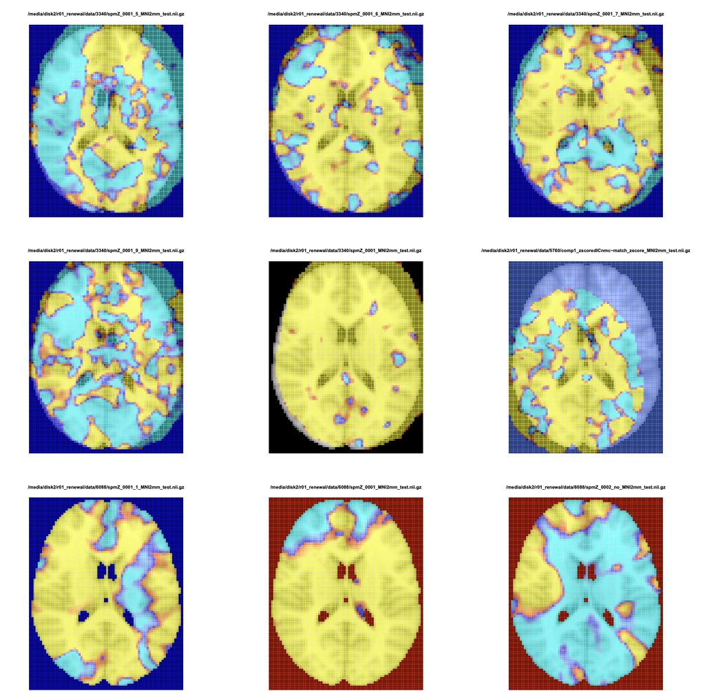

To resolve the misalignment of reslicing, we evaluated registration of varying complexity:

- **Reslicing** – no registration is performed; the image is simply resampled into the MNI 2mm grid.
- **Rigid registration (DOF = 6)** – allows only rotation and translation, preserving the original shape and scale of the brain.
- **Affine registration (DOF = 12)** – adds scaling and shearing to the rigid transform.

For both rigid and linear registrations, we use mutual information (MI) as the cost function (`-cost mutualinfo` in FLIRT) to accommodate differences in contrast and intensity between the template and statistical images. Results are shown for the seven most common dimensions covering majority of the dataset, to get a snapshot of what they would look like under different registration methods.

```r
library(neurobase)
library(grid)
library(gridGraphics)
library(cowplot)
library(ggplot2)

stopifnot(exists("template"), file.exists(template))
mni <- readNIfTI(template)

images_subset <- readRDS("proportionalimagesubset_Section3.1.3.rds")
images_subset$dim_mm <- as.character(images_subset$dim_mm)

# @haozheng, this is hard coded, so should maybe be derived from the data directly
dims_to_show <- c("182*218*182","195*231*196",
                  "194*230*194","195*231*195","192*228*192","158*190*158","195*232.5*195")

redmap <- colorRampPalette(c("blue","red","yellow"))(256)

first_existing <- function(v) {
  v <- v[!is.na(v)]
  i <- which(file.exists(v))
  if (length(i)) v[i[1]] else NA_character_
}

ortho2_grob <- function(bg, ovl, title, zlims) {
  grid.echo(function() {
    op <- par(mai = c(0.1, 0.1, 0.55, 0.2), cex.main = 0.75)
    on.exit(par(op), add = TRUE)
    ortho2(bg, ovl,
           col.x = gray(0:64/64),
           col.y = redmap,
           text  = title,
           text.cex = 0.8,
           NA.x = TRUE, NA.y = TRUE,
           ycolorbar = TRUE,
           zlim.y = zlims)
  })
  grid.grab()
}

has_flirt <- nzchar(Sys.which("flirt"))

grobs  <- list()
labels <- character(0)

for (d in dims_to_show) {
  img_file <- first_existing(images_subset$localfile[images_subset$dim_mm == d])
  if (is.na(img_file)) {
    message("No files for dim_mm = ", d)
    next
  }

  # initialize panels
  gR <- gL <- gS <- ggplot() + theme_void() +
    annotate("text", x = 0, y = 0, label = "No panel", size = 5)

  if (!is.na(img_file) && has_flirt) {
    out1 <- tempfile(fileext = "_rigid.nii.gz")
    out2 <- tempfile(fileext = "_affine.nii.gz")
    out3 <- tempfile(fileext = "_reslice.nii.gz")

    # Rigid
    system2("flirt", c("-in", img_file, "-ref", template,
                       "-out", out1, "-dof", "6",
                       "-cost", "mutualinfo", "-interp", "trilinear"))
    if (file.exists(out1)) {
      stat6 <- readNIfTI(out1)
      z6 <- quantile(stat6, probs = c(0.7, 1.0), na.rm = TRUE)
      stat6[stat6 < z6[1]] <- NA
      gR <- ggdraw(ortho2_grob(mni, stat6,
                paste0("Rigid (DOF=6) — \n", gsub("\\*", "×", d)), z6))
    }

    # Linear
    system2("flirt", c("-in", img_file, "-ref", template,
                       "-out", out2, "-dof", "12",
                       "-cost", "mutualinfo", "-interp", "trilinear"))
    if (file.exists(out2)) {
      stat12 <- readNIfTI(out2)
      z12 <- quantile(stat12, probs = c(0.7, 1.0), na.rm = TRUE)
      stat12[stat12 < z12[1]] <- NA
      gL <- ggdraw(ortho2_grob(mni, stat12,
                paste0("Linear (DOF=12) — \n", gsub("\\*", "×", d)), z12))
    }

    # Reslice (2 mm isotropic)
    system2("flirt", c("-in", img_file, "-ref", template,
                       "-out", out3, "-applyisoxfm", "2",
                       "-interp", "trilinear"))
    if (file.exists(out3)) {
      stat_reslice <- readNIfTI(out3)
      z_reslice <- quantile(stat_reslice, probs = c(0.7, 1.0), na.rm = TRUE)
      stat_reslice[stat_reslice < z_reslice[1]] <- NA
      gS <- ggdraw(ortho2_grob(mni, stat_reslice,
                paste0("Reslicing (2mm) — \n", gsub("\\*", "×", d)), z_reslice))
    }
  } else if (!has_flirt) {
    gS <- gR <- gL <- ggplot() + theme_void() +
      annotate("text", x = 0, y = 0, label = "FLIRT not found on PATH", size = 5)
  }

  # Save panels
  row_plot <- plot_grid(gS, gR, gL, ncol = 3, greedy = FALSE)
  grobs[[length(grobs) + 1]] <- row_plot
  labels <- c(labels, gsub("\\*", "×", d))

  outfile <- sprintf("registrations_%s.png", gsub("\\*", "x", d))
  ggsave(outfile, row_plot, width = 15, height = 3, dpi = 1000, limitsize = FALSE)
  message("Saved: ", outfile)
}
```

## 4.1 Registration snapshots

### 4.1.1 158x190x158

[figure not shown]

### 4.1.2 182x218x182

[figure not shown]

### 4.1.3 192x228x192

[figure not shown]

### 4.1.4 194x230x194

[figure not shown]

### 4.1.5 195x231x195

[figure not shown]

### 4.1.6 195x231x196

[figure not shown]

### 4.1.7 195x232.5x195

[figure not shown]

Based on these results, we chose rigid registration, as a balance between flexibility and accuracy across the categories. With the registered images, we further extracted information from the data:

- `voxdim_new`: indicates the new voxel dimension of the images, now all images should be 2mm isotropic.
- `imgdim_new`: indicates the new image dimension, now all images should be `91*109*91`.
- `range_new`: indicates the new range of voxel intensity.

```r
library(RNifti)
library(oro.nifti)
library(pbapply)
library(parallel)
outdir = '/media/big/neurovault'
images <- readRDS("proportionalimagesubset_Section3.1.3.rds")

## FSL Setup - Robust
if (!nzchar(Sys.which("flirt"))) {
  if (!nzchar(Sys.getenv("FSLDIR"))) {
    fsl_candidates <- c("/usr/local/fsl", "/usr/share/fsl", "/opt/fsl")
    existing <- file.exists(fsl_candidates)
    if (any(existing)) {
      Sys.setenv(FSLDIR = fsl_candidates[which(existing)[1]])
    } else {
      stop("FSL not found. Please install FSL and set FSLDIR environment variable")
    }
  }
  Sys.setenv(FSLOUTPUTTYPE = "NIFTI_GZ")
  fslbin <- file.path(Sys.getenv("FSLDIR"), "bin")
  Sys.setenv(PATH = paste(fslbin, Sys.getenv("PATH"), sep = ":"))
}

## Reference image
ref <- file.path(Sys.getenv("FSLDIR"), "data", "standard", "MNI152_T1_2mm_brain.nii.gz")

## Configuration
top_dir <- outdir

## Helpers
outname <- function(f, tag = "_rigid_cost_step1") {
  out_dir <- dirname(f)
  base_name <- sub("\\.nii(\\.gz)?$", "", basename(f), ignore.case = TRUE)
  file.path(out_dir, paste0(base_name, tag, ".nii.gz"))
}

validate_flirt <- function() {
  flirt <- Sys.which("flirt")
  if (!nzchar(flirt)) stop("FLIRT not found in PATH")
  if (system2(flirt, args = "-version", stdout = FALSE, stderr = FALSE) != 0) {
    stop("FLIRT exists but failed to run. Please check FSL installation")
  }
  flirt
}

flirt <- validate_flirt()  ## Moved up here

reslice_image <- function(input, output, ref) {
  if (!file.exists(output)) {
    message(sprintf("Reslicing: %s", basename(input)))
    cmd <- sprintf("%s -in '%s' -ref '%s' -out '%s' -dof 6 -cost mutualinfo -interp trilinear",
                   flirt, input, ref, output)
    status <- system(cmd, ignore.stdout = TRUE, ignore.stderr = TRUE)
    if (status != 0 || !file.exists(output) || file.size(output) == 0) {
      warning("FLIRT failed for: ", input)
      return(NA_character_)
    }
  }
  return(output)
}

## Generate resliced output paths
images$resliced <- vapply(images$localfile, outname, character(1))

## Reslice
results <- mcmapply(
  FUN = reslice_image,
  input = images$localfile,
  output = images$resliced,
  MoreArgs = list(ref = ref),
  mc.cores = n_cores
)

## Store results
images$resliced_path[!is.na(results)] <- unlist(results[!is.na(results)])

## Save final
saveRDS(images, "proportionalimagesubset_Section3.2.rds")
```

```r
library(stringr)
resliced_images2 <- readRDS("proportionalimagesubset_Section3.2.rds")

cmd_vox <- paste('/usr/local/c3d-1.1.0-Linux-x86_64/bin/c3d', resliced_images2$resliced_path, '-threshold 0 0 0 1 -voxel-sum')
nvox <- unlist(mclapply(cmd_vox, system, intern = TRUE, mc.cores = n_cores))
resliced_images2$nvox_new_section3.2 <- as.numeric(gsub("[^0-9.]", "", nvox))

# Extract new info with c3d -info
cmd_info <- paste("/usr/local/c3d-1.1.0-Linux-x86_64/bin/c3d", resliced_images2$resliced_path, "-info")
info_resliced <- mclapply(cmd_info, system, intern = TRUE, mc.cores = n_cores)

extractField <- function(x, field_regex) {
  line <- x[1]
  match <- regmatches(line, regexpr(field_regex, line))
  return(match)
}

x <- resliced_images2$range_new

# pull the two numbers inside the brackets, robust to spaces & exponents

resliced_images2$voxdim_new <- sapply(info_resliced, extractField, "vox = \\[.*?\\]")
resliced_images2$imgdim_new <- sapply(info_resliced, extractField, "dim = \\[.*?\\]")
resliced_images2$orient_new <- sapply(info_resliced, extractField, "orient = [A-Z]+")
resliced_images2$range_new  <- sapply(info_resliced, extractField, "range = \\[.*?\\]")

saveRDS(resliced_images2, "proportionalimagesubset_Section3.3.rds")
```

## 4.2 Registration quality control

From the above section, we found two types of abnormal images to take care of: * 1. Images with NaN values. * 2. Images with values everywhere (including inside and outside the brain), which is the ones with very high values of non-zero voxels.

To take care of the images with active voxels everywhere, we set a fixed $\varepsilon$ (0.0003) here, to filter out voxels with values around zero by $\varepsilon$ in all images. Our rationale behind such an epsilon selection is that most of the images with active voxels everywhere has very low values outside the brain, usually around 0.00003. Therefore, filtering out everything around zero by 0.0003 would ideally set every voxel outside to be zero. Moreover, even if some voxels inside the brain are accidentally set to zero because of this, given its extremely low value, it would also be fine for us to simply set them to be zero.

```r
resliced_images2 <- readRDS("proportionalimagesubset_Section3.3.rds")

# Convert NaN into zeros
cmd <- paste('/usr/local/c3d-1.1.0-Linux-x86_64/bin/c3d', resliced_images2$resliced_path, '-replace NaN 0.0 -o', resliced_images2$resliced_path)

eps <- 3e-4

files_all <- resliced_images2$resliced_path
keep  <- !is.na(files_all) & file.exists(files_all)
files <- files_all[keep]

# new output names next to originals:
outs  <- sub("\\.nii(\\.gz)?$", "_eps.nii.gz", files, ignore.case = TRUE)

cmd <- sprintf("%s %s -dup -threshold -%g %g 0 1 -multiply -o %s",
               shQuote("/usr/local/c3d-1.1.0-Linux-x86_64/bin/c3d"),
               shQuote(files), eps, eps, shQuote(outs))

invisible(parallel::mclapply(cmd, function(c) system(paste(c, "2>&1"), intern = TRUE),
                             mc.cores = n_cores))

resliced_images2$eps_path <- NA_character_
resliced_images2$eps_path[keep] <- outs

cmd_vox <- paste('/usr/local/c3d-1.1.0-Linux-x86_64/bin/c3d', resliced_images2$eps_path, '-threshold 0 0 0 1 -voxel-sum')
nvox <- unlist(mclapply(cmd_vox, system, intern = TRUE, mc.cores = n_cores))

# The variable non_zero_voxels_section3.3 represent the number of non-zero after the above two manipulations
resliced_images2$non_zero_voxels_new <- as.numeric(gsub("[^0-9.]", "", nvox))

saveRDS(resliced_images2, "proportionalimagesubset_Section3.3.rds")
```

Until this point, since we have manipulated the number of non-zero voxels even further by thresholding above 0.0003, and removed the NaN voxels, it’s necessary to have a new measure over the number of non-zero voxels: * `non_zero_voxels_new`: indicates the number of non-zero voxels after the above manipulations.

## 4.3 Exclusionary criteria based on coverage

```r
library(parallel)

n_cores <- min(24, max(1, parallel::detectCores() - 2))

# Mask files
gm_mask <- "/media/disk2/ree/grey_matter_binary_mask.nii.gz"
wm_mask <- "/media/disk2/ree/white_matter_binary_mask.nii.gz"
mask_2mm_file <- "/media/disk2/ree/brain_binary_mask.nii.gz"
mask_2mm_file_complement <- "/media/disk2/ree/brain_binary_mask_complement.nii.gz"

# Paths
c3d_bin <- "/usr/local/c3d-1.1.0-Linux-x86_64/bin/c3d"

# Load metadata
resliced_images2 <- readRDS("proportionalimagesubset_Section3.3.rds")

files_all <- resliced_images2$eps_path
keep <- !is.na(files_all) & file.exists(files_all)
files <- files_all[keep]
idx   <- which(keep)

# Build vectorized commands: (image nonzero->1) * (mask) -> voxel-sum
mk_cmd <- function(mask_path) {
  sprintf('%s %s -threshold 0 0 0 1 %s -multiply -voxel-sum',
          c3d_bin, files, mask_path)
}


cmd_outside <- mk_cmd(mask_2mm_file_complement)
cmd_gm      <- mk_cmd(gm_mask)
cmd_wm      <- mk_cmd(wm_mask)

nnz_outside <- unlist(mclapply(cmd_outside, system, intern = TRUE, mc.cores = n_cores))
nnz_gm      <- unlist(mclapply(cmd_gm,      system, intern = TRUE, mc.cores = n_cores))
nnz_wm      <- unlist(mclapply(cmd_wm,      system, intern = TRUE, mc.cores = n_cores))

nvox_outside <- nnz_outside
nvox_gm      <- nnz_gm
nvox_wm      <- nnz_wm

# Write back (order-preserving; NAs for missing files)
resliced_images2$nvox_outside[idx] <- nvox_outside
resliced_images2$nvox_gm[idx]      <- nvox_gm
resliced_images2$nvox_wm[idx]      <- nvox_wm

cols <- c("nvox_outside","nvox_gm","nvox_wm")
resliced_images2[, (cols) := lapply(as.data.frame(resliced_images2[, ..cols]),
                                    function(x) as.numeric(sub(".*?([-+0-9.eE]+)\\s*$","\\1", x)))]


# Save updated metadata
saveRDS(resliced_images2, "proportionalimagesubset_Section3.4.1.rds")
```

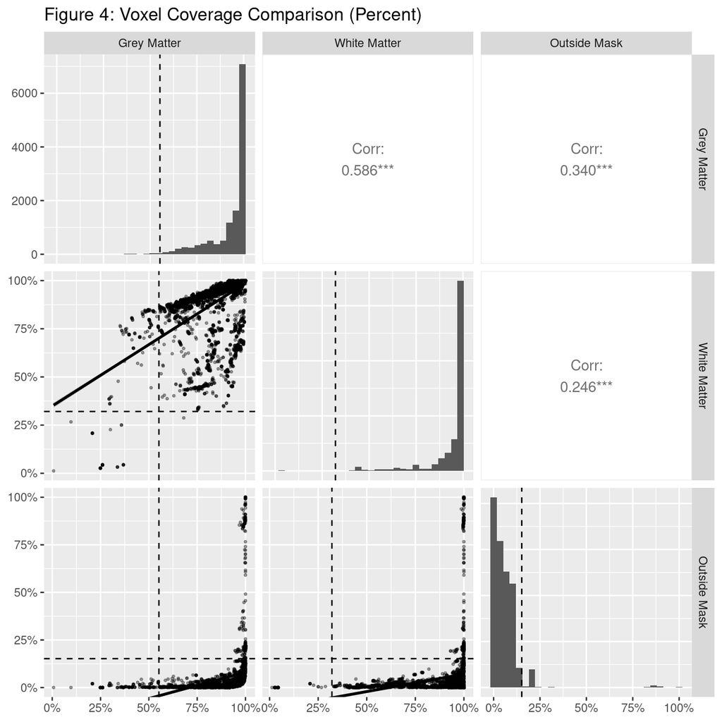

```r
# thresholds
GM_MIN  <- 100000
WM_MIN  <- 20000
OUT_MAX <- 100000

gm_mask <- "/media/disk2/ree/grey_matter_binary_mask.nii.gz"
GM_total <- sum(readNifti(gm_mask))

wm_mask <- "/media/disk2/ree/white_matter_binary_mask.nii.gz"
WM_total <- sum(readNifti(wm_mask))

resliced_images2 <- readRDS("proportionalimagesubset_Section3.4.1.rds")

out_total <- 91*109*91 - GM_total - WM_total
resliced_images2$gm_perc <- resliced_images2$nvox_gm / GM_total
resliced_images2$wm_perc <- resliced_images2$nvox_wm / WM_total
resliced_images2$outside_perc <- resliced_images2$nvox_outside / out_total


library(GGally)
library(ggplot2)
library(scales)
library(rlang)
# --- proportions already computed above ---
coverage_df <- resliced_images2[, c("gm_perc", "wm_perc", "outside_perc")]
coverage_df <- na.omit(coverage_df)

colnames(coverage_df) <- c("Grey Matter", "White Matter", "Outside Mask")

# convert to percent for plotting
coverage_pct <- coverage_df * 100

# convert voxel-count thresholds to percent thresholds
ref_pct <- c(
  "Grey Matter"  = 100 * GM_MIN  / GM_total,
  "White Matter" = 100 * WM_MIN  / WM_total,
  "Outside Mask" = 100 * OUT_MAX / out_total
)

# formatter for axes
pct_lab <- scales::label_percent(scale = 1, accuracy = 1)  # since data already in 0-100

diag_fun <- function(data, mapping, ...) {
  p <- GGally::ggally_barDiag(data, mapping, ...)
  var <- as_label(mapping$x)
  thr <- ref_pct[[var]]
  if (!is.null(thr)) p <- p + geom_vline(xintercept = thr, linetype = "dashed")
  p + scale_x_continuous(labels = pct_lab)
}

lower_fun <- function(data, mapping, ...) {
  p <- GGally::ggally_smooth(data, mapping, ...)
  xvar <- as_label(mapping$x); yvar <- as_label(mapping$y)

  if (!is.null(ref_pct[[xvar]])) p <- p + geom_vline(xintercept = ref_pct[[xvar]], linetype = "dashed")
  if (!is.null(ref_pct[[yvar]])) p <- p + geom_hline(yintercept = ref_pct[[yvar]], linetype = "dashed")

  p +
    scale_x_continuous(labels = pct_lab) +
    scale_y_continuous(labels = pct_lab)
}

upper_fun <- function(data, mapping, ...) {
  GGally::ggally_cor(data, mapping, ...) +
    theme_void()
}

GGally::ggpairs(
  coverage_pct,
  title = "Figure 4: Voxel Coverage Comparison (Percent)",
  upper = list(continuous = "cor"),
  diag  = list(continuous = diag_fun),
  lower = list(continuous = wrap(lower_fun, alpha = 0.35, size = 0.6))
)
```

We perform further exclusions based on coverage information of the rigidly registered images based on the following metrics:

1. Proportion of nonzero voxels inside the gray matter above 55%.
2. Proportion of nonzero voxels inside the white matter above 32%.
3. Proportion of nonzero voxels outside gray and white below 15%.

```r
resliced_images2 <- readRDS("proportionalimagesubset_Section3.4.1.rds")

# coerce just in case
resliced_images2$nvox_gm      <- as.numeric(resliced_images2$nvox_gm)
resliced_images2$nvox_wm      <- as.numeric(resliced_images2$nvox_wm)
resliced_images2$nvox_outside <- as.numeric(resliced_images2$nvox_outside)

# keep ONLY rows that pass all three checks (and are finite)
keep <- with(resliced_images2,
             is.finite(nvox_gm) & nvox_gm >= GM_MIN &
             is.finite(nvox_wm) & nvox_wm >= WM_MIN &
             is.finite(nvox_outside) & nvox_outside <= OUT_MAX)

resliced_images2 <- resliced_images2[keep, , drop = FALSE]
cat("Kept:", sum(keep), "  Dropped:", sum(!keep), "\n")

# save the filtered dataset
saveRDS(resliced_images2, "proportionalimagesubset_Section3.5.rds")
```

The following shows what the dataset looks like after excluding.

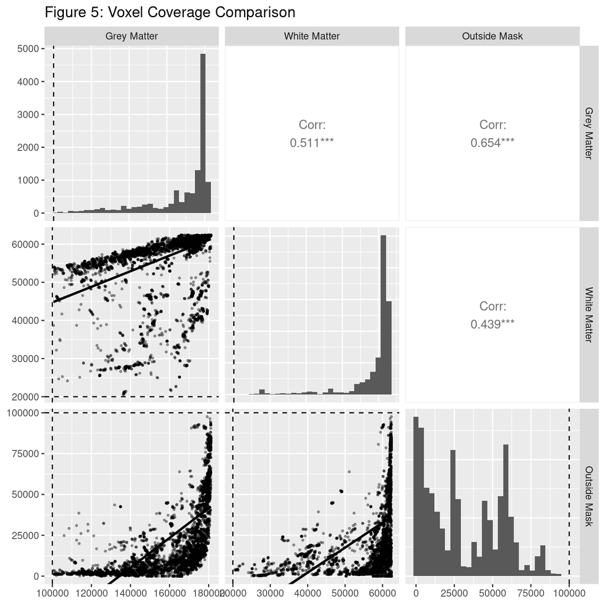

```r
resliced_images2 = readRDS("proportionalimagesubset_Section3.5.rds")

# Select relevant columns for plotting
coverage_df <- resliced_images2[, c("nvox_gm", "nvox_wm", "nvox_outside")]

# Ensure no NAs and all numeric
coverage_df <- na.omit(coverage_df)

colnames(coverage_df) <- c("Grey Matter", "White Matter", "Outside Mask")
library(GGally)

library(rlang)  # for as_label()

# thresholds for each variable
ref <- c("Grey Matter" = GM_MIN,
         "White Matter" = WM_MIN,
         "Outside Mask" = OUT_MAX)

# diagonal: histogram + vertical dashed line at the var's threshold
diag_fun <- function(data, mapping, ...) {
  p <- GGally::ggally_barDiag(data, mapping, ...)
  var <- as_label(mapping$x)
  thr <- ref[[var]]
  if (!is.null(thr)) p <- p + geom_vline(xintercept = thr, linetype = "dashed")
  p
}

# lower: smooth scatter + vline/hline at the x/y thresholds
lower_fun <- function(data, mapping, ...) {
  p <- GGally::ggally_smooth(data, mapping, ...)
  xvar <- as_label(mapping$x); yvar <- as_label(mapping$y)
  if (!is.null(ref[[xvar]])) p <- p + geom_vline(xintercept = ref[[xvar]], linetype = "dashed")
  if (!is.null(ref[[yvar]])) p <- p + geom_hline(yintercept = ref[[yvar]], linetype = "dashed")
  p
}

ggpairs(
  coverage_df,
  title = "Figure 5: Voxel Coverage Comparison",
  upper = list(continuous = "cor"),
  diag  = list(continuous = diag_fun),
  lower = list(continuous = wrap(lower_fun, alpha = 0.35, size = 0.6))
)
```

# 5 Effect size analysis and exclusionary criteria

Here, we convert nonzero values in the T and Z statistical images into the signed version of the robust effect size index (RESI; using `RESI::t2S` for T maps and `RESI::z2S` for Z maps), based on each metadata sample size reported with the images. We save the resulting effect size images and summary statistics within gray and white matter (mean, min, max, and quartiles (0.25, 0.5, 0.75)), are computed to perform image quality evaluation. Given that registration of the prior step could potentially break some images, we perform a simple exclusion based on missingness of data entries.

```r
library(RNifti)
library(parallel)
library(RESI)

# Load masks once
gm_mask <- RNifti::readNifti("/media/disk2/ree/grey_matter_binary_mask.nii.gz")
wm_mask <- RNifti::readNifti("/media/disk2/ree/white_matter_binary_mask.nii.gz")

# Load dataset
resliced_meaningful_images <- readRDS("proportionalimagesubset_Section3.5.rds")
resliced_meaningful_images <- resliced_meaningful_images[!is.na(resliced_meaningful_images$number_of_subjects), ]

# Predefine output columns
num_cols <- c("es_min","es_1qt","es_median","es_3qt","es_max","es_mean",
              "grey_mean","grey_min","grey_max",
              "white_mean","white_min","white_max")
for (nm in num_cols) resliced_meaningful_images[[nm]] <- NA_real_
resliced_meaningful_images$effect_size_file <- NA_character_
resliced_meaningful_images$grey_file        <- NA_character_
resliced_meaningful_images$white_file       <- NA_character_

# Parallel cores
n_cores <- 24

# Main computation
results <- mclapply(seq_len(nrow(resliced_meaningful_images)), function(i) {
  tryCatch({
    file_path <- resliced_meaningful_images$eps_path[i]
    if (is.na(file_path) || !nzchar(file_path) || !file.exists(file_path)) return(NULL)

    n_subj   <- resliced_meaningful_images$number_of_subjects[i]
    map_type <- as.character(resliced_meaningful_images$map_type[i])

    img <- RNifti::readNifti(file_path)

    nonzero_mask <- (img != 0) & !is.na(img)
    valid_vals   <- img[nonzero_mask]
    effect_img   <- img

    if (identical(map_type, "T map")) {
      effect_img[nonzero_mask] <- RESI::t2S(valid_vals, rdf = n_subj - 1, n = n_subj)
    } else if (identical(map_type, "Z map")) {
      effect_img[nonzero_mask] <- RESI::z2S(valid_vals, n = n_subj, unbiased = TRUE)
    } else {
      return(NULL)
    }

    effect_img[!is.finite(effect_img)] <- 0

    output_dir <- dirname(file_path)
    if (!dir.exists(output_dir)) dir.create(output_dir, recursive = TRUE)
    base_name  <- sub("\\.nii\\.gz$", "", basename(file_path))
    out_file   <- file.path(output_dir, paste0(base_name, "_effect_size.nii.gz"))
    RNifti::writeNifti(effect_img, out_file)

    es_vals <- effect_img[effect_img != 0 & !is.na(effect_img)]
    es_stats <- if (length(es_vals) > 0) {
      c(
        es_min    = min(es_vals),
        es_1qt    = as.numeric(stats::quantile(es_vals, 0.25, type = 7, names = FALSE)),
        es_median = median(es_vals),
        es_3qt    = as.numeric(stats::quantile(es_vals, 0.75, type = 7, names = FALSE)),
        es_max    = max(es_vals),
        es_mean   = mean(es_vals)
      )
    } else rep(NA_real_, 6)

    grey_masked  <- effect_img * gm_mask
    white_masked <- effect_img * wm_mask
    grey_vals    <- grey_masked[grey_masked != 0]
    white_vals   <- white_masked[white_masked != 0]

    grey_file  <- sub("\\.nii\\.gz$", "_masked_grey_after_es.nii.gz", out_file)
    white_file <- sub("\\.nii\\.gz$", "_masked_white_after_es.nii.gz", out_file)
    RNifti::writeNifti(grey_masked,  grey_file)
    RNifti::writeNifti(white_masked, white_file)

    list(
      index       = i,
      effect_size_file = out_file,
      grey_file   = grey_file,
      white_file  = white_file,
      es_min      = es_stats[1],
      es_1qt      = es_stats[2],
      es_median   = es_stats[3],
      es_3qt      = es_stats[4],
      es_max      = es_stats[5],
      es_mean     = es_stats[6],
      grey_mean   = if (length(grey_vals)  > 0) mean(grey_vals)  else NA_real_,
      grey_min    = if (length(grey_vals)  > 0) min(grey_vals)   else NA_real_,
      grey_max    = if (length(grey_vals)  > 0) max(grey_vals)   else NA_real_,
      white_mean  = if (length(white_vals) > 0) mean(white_vals) else NA_real_,
      white_min   = if (length(white_vals) > 0) min(white_vals)  else NA_real_,
      white_max   = if (length(white_vals) > 0) max(white_vals)  else NA_real_
    )
  }, error = function(e) {
    message(" Skipping index ", i, ": ", e$message)
    NULL
  })
}, mc.cores = n_cores)

# Filter and bind
results <- Filter(Negate(is.null), results)
df_results <- do.call(rbind, lapply(results, as.data.frame))
df_results$index <- as.integer(df_results$index)

# Match and update
cols_to_update <- intersect(names(df_results), names(resliced_meaningful_images))
for (nm in setdiff(cols_to_update, "index")) {
  resliced_meaningful_images[df_results$index, nm] <- df_results[[nm]]
}

# Save final dataset
saveRDS(resliced_meaningful_images, "proportionalimagesubset_Section4.1.rds")
```

The mean value of the effect size is proportional to $n_i^{-1} V_i^{-2}$, where $n_i$ denotes the number of subjects (sample size) and $V_i$ denotes the number of nonzero voxels in study $i$.

After converting each study’s test-statistic image to an effect-size image, we summarize each image by its mean effect size within gray matter (GM) and white matter (WM). To screen for implausible or artifactual images, we model the expected variability of these mean effect sizes as a function of (i) study sample size and (ii) voxel coverage, and flag observations that fall outside the implied funnel.

Let $y_{ij}$ denote the observed mean effect size for image $j$ from collection $c[i]$. We fit an intercept-only linear mixed-effects model with a collection-specific random intercept:

$$y_{ij} = \mu + u_{c[i]} +
\varepsilon_{ij},$$

where $\mu$ is the grand mean effect size and $u_{c[i]} \sim \mathcal{N}(0, \tau^2)$ captures between-collection heterogeneity.

$$\mathrm{Var}(\varepsilon_{ij}) =
\sigma^2 \, |N_{ij}|^{2\delta_1} \, |V_{ij}|^{2\delta_2},$$

so that residual variability decreases as $N$ and/or $V$ increase when $\delta_1 < 0$ and/or $\delta_2 < 0$.

The total per-observation variance (and thus the width of the funnel) incorporates both residual and between-collection variability:

$$SD_{ij}^2 = \tau^2 + \sigma^2 \,
|N_{ij}|^{2\delta_1} \, |V_{ij}|^{2\delta_2}.$$

Outlier detection rule. We flag an observation as an outlier if its deviation from the fitted grand mean exceeds a multiple of its modeled standard deviation:

$$\bigl| y_{ij} - \hat{\mu} \bigr| > k
\, SD_{ij},$$

with $k = 3$. Equivalently, outliers are defined as observations lying outside the funnel boundaries $\hat{\mu} \pm k \, SD_{ij}$.

These analyses serve both to validate the effect-size transformation and to provide a principled, model-based mechanism for identifying implausible images prior to downstream inference. While alternative filtering strategies were explored, we selected the mixed-effects variance modeling approach as the most statistically grounded and interpretable method for screening artifactual data points. A summary table consolidating key model estimates and variance components is provided below.

```r
library(dplyr)
library(RNifti)
library(knitr)

resliced_images2 <- readRDS("proportionalimagesubset_Section4.1.rds")

GM_total <- sum(readNifti("/media/disk2/ree/grey_matter_binary_mask.nii.gz"))
WM_total <- sum(readNifti("/media/disk2/ree/white_matter_binary_mask.nii.gz"))
OUT_total <- 91 * 109 * 91 - GM_total - WM_total

q <- function(x) quantile(x, c(.25, .5, .75), na.rm = TRUE)

n_images <- nrow(resliced_images2)
n_collections <- dplyr::n_distinct(resliced_images2$collection_id)

N   <- resliced_images2$number_of_subjects
gm  <- resliced_images2$nvox_gm
wm  <- resliced_images2$nvox_wm
out <- resliced_images2$nvox_outside

es_gm <- resliced_images2$grey_mean
es_wm <- resliced_images2$white_mean

summary_tbl <- data.frame(
  Statistic = c(
    "Number of images",
    "Number of collections",
    "Sample size, median [Q1, Q3]",
    "Gray matter coverage, median % [Q1, Q3]",
    "White matter coverage, median % [Q1, Q3]",
    "Outside-mask coverage, median % [Q1, Q3]",
    "Gray matter mean effect size, median [Q1, Q3]",
    "White matter mean effect size, median [Q1, Q3]"
  ),
  Value = c(
    n_images,
    n_collections,
    sprintf("%.0f [%.0f, %.0f]", q(N)[2], q(N)[1], q(N)[3]),
    sprintf("%.2f%% [%.2f, %.2f]",
            100*q(gm/GM_total)[2], 100*q(gm/GM_total)[1], 100*q(gm/GM_total)[3]),
    sprintf("%.2f%% [%.2f, %.2f]",
            100*q(wm/WM_total)[2], 100*q(wm/WM_total)[1], 100*q(wm/WM_total)[3]),
    sprintf("%.2f%% [%.2f, %.2f]",
            100*q(out/OUT_total)[2], 100*q(out/OUT_total)[1], 100*q(out/OUT_total)[3]),
    sprintf("%.3f [%.3f, %.3f]", q(es_gm)[2], q(es_gm)[1], q(es_gm)[3]),
    sprintf("%.3f [%.3f, %.3f]", q(es_wm)[2], q(es_wm)[1], q(es_wm)[3])
  ),
  stringsAsFactors = FALSE
)

knitr::kable(summary_tbl, caption = "Summary statistics for effect-size screening")
```

Summary statistics for effect-size screening

| Statistic | Value |
| --- | --- |
| Number of images | 12188 |
| Number of collections | 3255 |
| Sample size, median [Q1, Q3] | 30 [18, 53] |
| Gray matter coverage, median % [Q1, Q3] | 97.96% [91.22, 99.20] |
| White matter coverage, median % [Q1, Q3] | 98.85% [94.56, 99.54] |
| Outside-mask coverage, median % [Q1, Q3] | 3.64% [1.18, 8.42] |
| Gray matter mean effect size, median [Q1, Q3] | 0.004 [-0.037, 0.055] |
| White matter mean effect size, median [Q1, Q3] | 0.001 [-0.037, 0.039] |

## 5.1 Winsorizing and further exclusion

Due to the extremely large residual, we perform winsorizing to the dataset to get rid of entries beyond 1th and 99th percentiles, and then fit the mixed effect model to further exclude outliers. The resulting dataset would be our final dataset.

```r
library(nlme)

winsorize_vec <- function(x, probs = c(0.01, 0.99)) {
  qs <- quantile(x, probs = probs, na.rm = TRUE, names = FALSE, type = 7)
  x[x < qs[1]] <- qs[1]
  x[x > qs[2]] <- qs[2]
  x
}

images <- readRDS("/media/disk2/ree/metadataset/proportionalimagesubset_Section4.1.rds")
images$es_mean <- winsorize_vec(images$es_mean)
images$voxel_scaled <- images$non_zero_voxels_section3.3/1000

images_original <- readRDS("/media/disk2/ree/metadataset/proportionalimagesubset_Section4.1.rds")

images_original$voxel_scaled <- images_original$non_zero_voxels_section3.3/1000

m_power_winsorized <- lme(
  es_mean ~ 1,
  random  = ~ 1 | collection_id,
  weights = varComb(
  varPower(form = ~ number_of_subjects),
  varPower(form = ~ voxel_scaled)),
  data    = images,
  method  = "REML"
)

m_power_original <- lme(
  es_mean ~ 1,
  random  = ~ 1 | collection_id,
  weights = varComb(
  varPower(form = ~ number_of_subjects),
  varPower(form = ~ voxel_scaled)),
  data    = images_original,
  method  = "REML"
)

summary(m_power_winsorized)
```

```
## Linear mixed-effects model fit by REML
##   Data: images
##         AIC       BIC   logLik
##   -21142.11 -21105.07 10576.06
##
## Random effects:
##  Formula: ~1 | collection_id
##         (Intercept) Residual
## StdDev:  0.06561541 26.56075
##
## Combination of variance functions:
##  Structure: Power of variance covariate
##  Formula: ~number_of_subjects
##  Parameter estimates:
##      power
## -0.1384238
##  Structure: Power of variance covariate
##  Formula: ~voxel_scaled
##  Parameter estimates:
##      power
## -0.9387265
## Fixed effects:  es_mean ~ 1
##                    Value   Std.Error   DF   t-value p-value
## (Intercept) -0.003290904 0.001575662 8933 -2.088585  0.0368
##
## Standardized Within-Group Residuals:
##         Min          Q1         Med          Q3         Max
## -5.93764090 -0.36881159  0.01955267  0.39434109  5.70314698
##
## Number of Observations: 12188
## Number of Groups: 3255
```

```r
summary(m_power_original)
```

```
## Linear mixed-effects model fit by REML
##   Data: images_original
##        AIC      BIC    logLik
##   7068.143 7105.184 -3529.072
##
## Random effects:
##  Formula: ~1 | collection_id
##         (Intercept)    Residual
## StdDev:   0.1678057 1.40395e+16
##
## Combination of variance functions:
##  Structure: Power of variance covariate
##  Formula: ~number_of_subjects
##  Parameter estimates:
##      power
## -0.1853501
##  Structure: Power of variance covariate
##  Formula: ~voxel_scaled
##  Parameter estimates:
##     power
## -6.835558
## Fixed effects:  es_mean ~ 1
##                   Value   Std.Error   DF   t-value p-value
## (Intercept) -0.01133958 0.003719123 8933 -3.048994  0.0023
##
## Standardized Within-Group Residuals:
##          Min           Q1          Med           Q3          Max
## -18.70835337  -0.10005601   0.01574824   0.15078291  30.92398415
##
## Number of Observations: 12188
## Number of Groups: 3255
```

```r
m_power <- m_power_winsorized
```

The following chunk uses the boundaries got from lmm outputs of winsorized dataset to make exclusions and the funnel plot.

```r
images <- readRDS("/media/disk2/ree/metadataset/proportionalimagesubset_Section4.1.rds")
images$es_mean <- winsorize_vec(images$es_mean)
images$voxel_scaled <- images$non_zero_voxels_section3.3/1000

dat <- images

m_power <- m_power_winsorized

overall_effect <- as.numeric(fixef(m_power))
sigma2 <- sigma(m_power)^2
tau2   <- as.numeric(VarCorr(m_power)[1, "Variance"])

# varPower exponents (delta_n, delta_v)
expParams <- intervals(m_power)$varStruct[, 2]
delta_n <- expParams[1]
delta_v <- expParams[2]

dat$se_model <- sqrt(
  tau2 + sigma2 *
    (dat$number_of_subjects ^ (2*delta_n)) *
    (dat$voxel_scaled       ^ (2*delta_v))
)

# standardized residuals
dat$res_std <- residuals(m_power, type = "pearson")

k <- 3
dat$outlier <- abs(dat$es_mean - overall_effect) > k * dat$se_model
dat$outlier[is.na(dat$outlier)] <- FALSE

dat_plot <- subset(
  dat,
  is.finite(number_of_subjects) & number_of_subjects > 0 &
    is.finite(es_mean) & is.finite(se_model)
)

dat_sorted <- dat_plot[order(dat_plot$number_of_subjects), ]
dat_clean  <- subset(dat_sorted, !outlier)

n_out <- sum(dat_plot$outlier)
n_tot <- nrow(dat_plot)

grid <- data.frame(
  number_of_subjects = seq(1, 10000, length.out = 800)
)

# choose a constant voxel_scaled for the band (median is a sensible default)
grid$voxel_scaled <- median(dat_plot$voxel_scaled, na.rm = TRUE)

grid$se_model <- sqrt(
  tau2 + sigma2 *
    (grid$number_of_subjects ^ (2*delta_n)) *
    (grid$voxel_scaled       ^ (2*delta_v))
)

grid$upper <- overall_effect + k * grid$se_model
grid$lower <- overall_effect - k * grid$se_model
grid$log_n <- log10(grid$number_of_subjects)

library(plotly)
dat_plot$se_model <- sqrt(
  tau2 + sigma2 *
    (dat_plot$number_of_subjects ^ (2 * delta_n)) *
    (dat_plot$voxel_scaled       ^ (2 * delta_v))
)

dat_plot$upper_bound <- overall_effect + k * dat_plot$se_model
dat_plot$lower_bound <- overall_effect - k * dat_plot$se_model

dat_plot$outlier <- with(dat_plot, es_mean > upper_bound | es_mean < lower_bound)

n_seq <- 10^seq(0, 4, length.out = 60)
v_seq <- seq(
  quantile(dat_plot$voxel_scaled, 0.05, na.rm = TRUE),
  quantile(dat_plot$voxel_scaled, 0.95, na.rm = TRUE),
  length.out = 60
)

grid3d <- expand.grid(number_of_subjects = n_seq, voxel_scaled = v_seq)

grid3d$se_model <- sqrt(
  tau2 + sigma2 *
    (grid3d$number_of_subjects ^ (2 * delta_n)) *
    (grid3d$voxel_scaled       ^ (2 * delta_v))
)

grid3d$upper <- overall_effect + k * grid3d$se_model
grid3d$lower <- overall_effect - k * grid3d$se_model


xg <- log10(n_seq)
yg <- v_seq

UP <- t(matrix(grid3d$upper, nrow = length(n_seq), ncol = length(v_seq)))
LO <- t(matrix(grid3d$lower, nrow = length(n_seq), ncol = length(v_seq)))
MU <- matrix(overall_effect, nrow = length(yg), ncol = length(xg))

plot_ly() |>
  add_markers(
    data = subset(dat_plot, !outlier),
    x = ~log10(number_of_subjects),
    y = ~voxel_scaled,
    z = ~es_mean,
    marker = list(size = 2, opacity = 0.25, color = "gray"),
    name = "Inside funnel"
  ) |>
  add_markers(
    data = subset(dat_plot, outlier),
    x = ~log10(number_of_subjects),
    y = ~voxel_scaled,
    z = ~es_mean,
    marker = list(size = 4, color = "red"),
    name = "Outliers"
  ) |>
  add_surface(
    x = xg, y = yg, z = MU,
    opacity = 0.35,
    name = "Overall effect (mu)"
  ) |>
  add_surface(
    x = xg, y = yg, z = UP,
    opacity = 0.20,
    showscale = FALSE,
    name = "Upper (mu + k·SD)"
  ) |>
  add_surface(
    x = xg, y = yg, z = LO,
    opacity = 0.20,
    showscale = FALSE,
    name = "Lower (mu - k·SD)"
  ) |>
  layout(
    scene = list(
      xaxis = list(title = "log10(sample size)"),
      yaxis = list(title = "voxel_scaled (nonzero voxels / 1e5)"),
      zaxis = list(title = "Effect size mean")
    )
  )
```

[interactive chart not shown]

```r
saveRDS(dat_clean, "proportionalimagesubset_Section4.2.rds")
```

## 5.2 Model refit with cleaned dataset

With the above exclusion, a new dataset is created with outliers excluded. The following chunk refits the model with the new dataset.

```r
dat_clean <- readRDS("proportionalimagesubset_Section4.2.rds")

m_power_winsorized_clean <- lme(
  es_mean ~ 1,
  random  = ~ 1 | collection_id,
  weights = varComb(
  varPower(form = ~ number_of_subjects),
  varPower(form = ~ voxel_scaled)),
  data    = dat_clean,
  method  = "REML"
)


dat <- dat_clean
m_power <- m_power_winsorized_clean

overall_effect <- as.numeric(fixef(m_power))
sigma2 <- sigma(m_power)^2
tau2   <- as.numeric(VarCorr(m_power)[1, "Variance"])

# varPower exponents (delta_n, delta_v)
expParams <- intervals(m_power)$varStruct[, 2]
delta_n <- expParams[1]
delta_v <- expParams[2]

dat$se_model <- sqrt(
  tau2 + sigma2 *
    (dat$number_of_subjects ^ (2*delta_n)) *
    (dat$voxel_scaled       ^ (2*delta_v))
)

# standardized residuals (optional panel A)
dat$res_std <- residuals(m_power, type = "pearson")

k <- 3
dat$outlier <- abs(dat$es_mean - overall_effect) > k * dat$se_model
dat$outlier[is.na(dat$outlier)] <- FALSE

dat_plot <- subset(
  dat,
  is.finite(number_of_subjects) & number_of_subjects > 0 &
    is.finite(es_mean) & is.finite(se_model)
)

dat_sorted <- dat_plot[order(dat_plot$number_of_subjects), ]
dat_clean  <- subset(dat_sorted, !outlier)

n_out <- sum(dat_plot$outlier)
n_tot <- nrow(dat_plot)

grid <- data.frame(
  number_of_subjects = seq(1, 10000, length.out = 800)
)

# choose a constant voxel_scaled for the band (median is a sensible default)
grid$voxel_scaled <- median(dat_plot$voxel_scaled, na.rm = TRUE)

grid$se_model <- sqrt(
  tau2 + sigma2 *
    (grid$number_of_subjects ^ (2*delta_n)) *
    (grid$voxel_scaled       ^ (2*delta_v))
)

grid$upper <- overall_effect + k * grid$se_model
grid$lower <- overall_effect - k * grid$se_model
grid$log_n <- log10(grid$number_of_subjects)

library(plotly)

dat_plot$se_model <- sqrt(
  tau2 + sigma2 *
    (dat_plot$number_of_subjects ^ (2 * delta_n)) *
    (dat_plot$voxel_scaled       ^ (2 * delta_v))
)

dat_plot$upper_bound <- overall_effect + k * dat_plot$se_model
dat_plot$lower_bound <- overall_effect - k * dat_plot$se_model

dat_plot$outlier <- with(dat_plot, es_mean > upper_bound | es_mean < lower_bound)

n_seq <- 10^seq(0, 4, length.out = 60)
v_seq <- seq(
  quantile(dat_plot$voxel_scaled, 0.05, na.rm = TRUE),
  quantile(dat_plot$voxel_scaled, 0.95, na.rm = TRUE),
  length.out = 60
)

grid3d <- expand.grid(number_of_subjects = n_seq, voxel_scaled = v_seq)

grid3d$se_model <- sqrt(
  tau2 + sigma2 *
    (grid3d$number_of_subjects ^ (2 * delta_n)) *
    (grid3d$voxel_scaled       ^ (2 * delta_v))
)

grid3d$upper <- overall_effect + k * grid3d$se_model
grid3d$lower <- overall_effect - k * grid3d$se_model


xg <- log10(n_seq)
yg <- v_seq

UP <- t(matrix(grid3d$upper, nrow = length(n_seq), ncol = length(v_seq)))
LO <- t(matrix(grid3d$lower, nrow = length(n_seq), ncol = length(v_seq)))
MU <- matrix(overall_effect, nrow = length(yg), ncol = length(xg))

plot_ly() |>
  add_markers(
    data = subset(dat_plot, !outlier),
    x = ~log10(number_of_subjects),
    y = ~voxel_scaled,
    z = ~es_mean,
    marker = list(size = 2, opacity = 0.25, color = "gray"),
    name = "Inside funnel"
  ) |>
  add_markers(
    data = subset(dat_plot, outlier),
    x = ~log10(number_of_subjects),
    y = ~voxel_scaled,
    z = ~es_mean,
    marker = list(size = 4, color = "red"),
    name = "Outliers"
  ) |>
  add_surface(
    x = xg, y = yg, z = MU,
    opacity = 0.35,
    name = "Overall effect (mu)"
  ) |>
  add_surface(
    x = xg, y = yg, z = UP,
    opacity = 0.20,
    showscale = FALSE,
    name = "Upper (mu + k·SD)"
  ) |>
  add_surface(
    x = xg, y = yg, z = LO,
    opacity = 0.20,
    showscale = FALSE,
    name = "Lower (mu - k·SD)"
  ) |>
  layout(
    scene = list(
      xaxis = list(title = "log10(sample size)"),
      yaxis = list(title = "voxel_scaled (nonzero voxels / 1e5)"),
      zaxis = list(title = "Effect size mean")
    )
  )
```

[interactive chart not shown]

```r
saveRDS(dat_clean, "dat_clean_from_refit_final.rds")
```

# 6 Table summary of the two lmm models

In this section, we have the model outputs of the two linear mixed effect models placed together to see the difference.

```r
library(dplyr)
library(knitr)
library(kableExtra)
```

```r
library(nlme)
library(tidyr)

dat <- readRDS("proportionalimagesubset_Section4.1.rds")
dat_clean <- readRDS("dat_clean_from_refit_final.rds")

dat$voxel_scaled <- dat$non_zero_voxels_section3.3 / 1000
dat_clean$voxel_scaled <- dat_clean$non_zero_voxels_section3.3 / 1000

extract_var_params <- function(fit) {
  sigma2 <- sigma(fit)^2
  tau2   <- as.numeric(VarCorr(fit)[1, "Variance"])

  expParams <- intervals(fit)$varStruct[, 2]
  delta_n <- expParams[1]
  delta_v <- expParams[2]

  data.frame(
    sigma2  = sigma2,
    tau2    = tau2,
    delta_n = delta_n,
    delta_v = delta_v
  )
}

m_full <- lme(
  es_mean ~ 1,
  random  = ~ 1 | collection_id,
  weights = varComb(
    varPower(form = ~ number_of_subjects),
    varPower(form = ~ voxel_scaled)
  ),
  data    = dat,
  method  = "REML"
)

m_clean <- lme(
  es_mean ~ 1,
  random  = ~ 1 | collection_id,
  weights = varComb(
    varPower(form = ~ number_of_subjects),
    varPower(form = ~ voxel_scaled)
  ),
  data    = dat_clean,
  method  = "REML"
)

tab_var <- bind_rows(
  `Before outlier exclusion` = extract_var_params(m_full),
  `After outlier exclusion`  = extract_var_params(m_clean),
  .id = "Dataset"
)

tab_display <- tab_var %>%
  transmute(
    Dataset,
    `log10(sigma^2)` = log10(sigma2),
    `tau^2`          = tau2,
    `delta_n`        = delta_n,
    `delta_v`        = delta_v
  ) %>%
  pivot_longer(
    cols = -Dataset,
    names_to = "Parameter",
    values_to = "Estimate"
  ) %>%
  mutate(
    Parameter = recode(
      Parameter,
      `log10(sigma^2)` = "$\\log_{10}(\\sigma^2)$",
      `tau^2`          = "$\\tau^2$",
      `delta_n`        = "$\\delta_n$",
      `delta_v`        = "$\\delta_v$"
    ),
    Estimate = case_when(
      Parameter == "$\\log_{10}(\\sigma^2)$" ~ sprintf("%.2f", Estimate),
      Parameter == "$\\tau^2$"               ~ sprintf("%.4f", Estimate),
      TRUE                                   ~ sprintf("%.3f", Estimate)
    )
  ) %>%
  pivot_wider(
    names_from  = Dataset,
    values_from = Estimate
  )

kable(
  tab_display,
  format = "html",
  escape = FALSE,
  align = c("l", "c", "c"),
  col.names = c(
    "Parameter",
    "Before outlier exclusion",
    "After outlier exclusion"
  ),
  caption = "Estimated variance components and heteroskedasticity exponents before and after outlier exclusion."
) %>%
  kable_styling(
    bootstrap_options = c("striped", "hover"),
    full_width = FALSE,
    position = "center"
  ) %>%
  footnote(
    general = "The residual variance component is reported on the log10 scale for readability because the uncleaned model produced an extremely large estimate of sigma^2."
  )
```

Estimated variance components and heteroskedasticity exponents before and after outlier exclusion.

| Parameter | Before outlier exclusion | After outlier exclusion |
| --- | --- | --- |
| $\log_{10}(\sigma^2)$ | 32.29 | 2.13 |
| $\tau^2$ | 0.0282 | 0.0012 |
| $\delta_n$ | -0.185 | -0.223 |
| $\delta_v$ | -6.836 | -0.786 |

Note:  
The residual variance component is reported on the log10 scale for readability because the uncleaned model produced an extremely large estimate of sigma^2.

## 6.1 Summary of the final dataset

```r
library(dplyr)
library(RNifti)
library(knitr)

resliced_images2 <- readRDS("dat_clean_from_refit_final.rds")

GM_total <- sum(readNifti("/media/disk2/ree/grey_matter_binary_mask.nii.gz"))
WM_total <- sum(readNifti("/media/disk2/ree/white_matter_binary_mask.nii.gz"))
OUT_total <- 91 * 109 * 91 - GM_total - WM_total

q <- function(x) quantile(x, c(.25, .5, .75), na.rm = TRUE)

n_images <- nrow(resliced_images2)
n_collections <- dplyr::n_distinct(resliced_images2$collection_id)

N   <- resliced_images2$number_of_subjects
gm  <- resliced_images2$nvox_gm
wm  <- resliced_images2$nvox_wm
out <- resliced_images2$nvox_outside

es_gm <- resliced_images2$grey_mean
es_wm <- resliced_images2$white_mean

summary_tbl <- data.frame(
  Statistic = c(
    "Number of images",
    "Number of collections",
    "Sample size, median [Q1, Q3]",
    "Gray matter coverage, median % [Q1, Q3]",
    "White matter coverage, median % [Q1, Q3]",
    "Outside-mask coverage, median % [Q1, Q3]",
    "Gray matter mean effect size, median [Q1, Q3]",
    "White matter mean effect size, median [Q1, Q3]"
  ),
  Value = c(
    n_images,
    n_collections,
    sprintf("%.0f [%.0f, %.0f]", q(N)[2], q(N)[1], q(N)[3]),
    sprintf("%.2f%% [%.2f, %.2f]",
            100*q(gm/GM_total)[2], 100*q(gm/GM_total)[1], 100*q(gm/GM_total)[3]),
    sprintf("%.2f%% [%.2f, %.2f]",
            100*q(wm/WM_total)[2], 100*q(wm/WM_total)[1], 100*q(wm/WM_total)[3]),
    sprintf("%.2f%% [%.2f, %.2f]",
            100*q(out/OUT_total)[2], 100*q(out/OUT_total)[1], 100*q(out/OUT_total)[3]),
    sprintf("%.3f [%.3f, %.3f]", q(es_gm)[2], q(es_gm)[1], q(es_gm)[3]),
    sprintf("%.3f [%.3f, %.3f]", q(es_wm)[2], q(es_wm)[1], q(es_wm)[3])
  ),
  stringsAsFactors = FALSE
)

knitr::kable(summary_tbl, caption = "Summary statistics for effect-size screening")
```

Summary statistics for effect-size screening

| Statistic | Value |
| --- | --- |
| Number of images | 11643 |
| Number of collections | 3172 |
| Sample size, median [Q1, Q3] | 30 [18, 54] |
| Gray matter coverage, median % [Q1, Q3] | 97.99% [91.38, 99.20] |
| White matter coverage, median % [Q1, Q3] | 98.84% [94.71, 99.53] |
| Outside-mask coverage, median % [Q1, Q3] | 3.64% [1.19, 8.45] |
| Gray matter mean effect size, median [Q1, Q3] | 0.004 [-0.035, 0.050] |
| White matter mean effect size, median [Q1, Q3] | 0.000 [-0.035, 0.034] |

```r
knitr::knit_exit()
```